# Assignment 6: Visualization - Aesthetic Mapping

*How to do it?*:

- Open the Rmarkdown file of this assignment (link) in Rstudio.
- Right under each **question**, insert a code chunk (you can use the hotkey `Ctrl + Alt + I` to add a code chunk) and code the solution for the question.
- `Knit` the rmarkdown file (hotkey: `Ctrl + Alt + K`) to export an html.
- Publish the html file to your Githiub Page.

*Submission*: Submit the link on Github of the assignment to Canvas.

### Questions on Your Selected Data

Choose a dataset and produce the following types of plots and comment on each plot. Plots should be meaningful. If you use the data we used in class, make sure the plots are not the same as the ones in the slides.

1. For one continuous variable:

```r
library(tidyverse)
```

```r
library(ggplot2)
df <- read_csv('https://bryantstats.github.io/math421/data/titanic.csv')
df <- df %>%
  mutate(Survived = as.character(Survived),
         Pclass = as.character(Pclass))
```

- Density

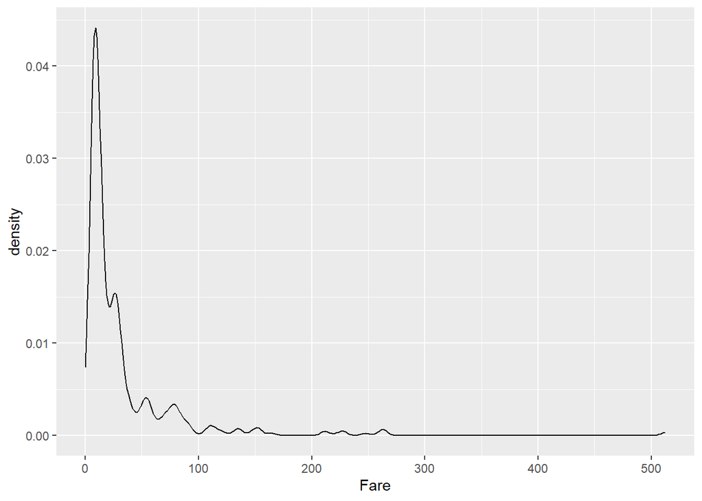

```r
df %>% ggplot()+
  geom_density(mapping = aes(x = Fare))
```

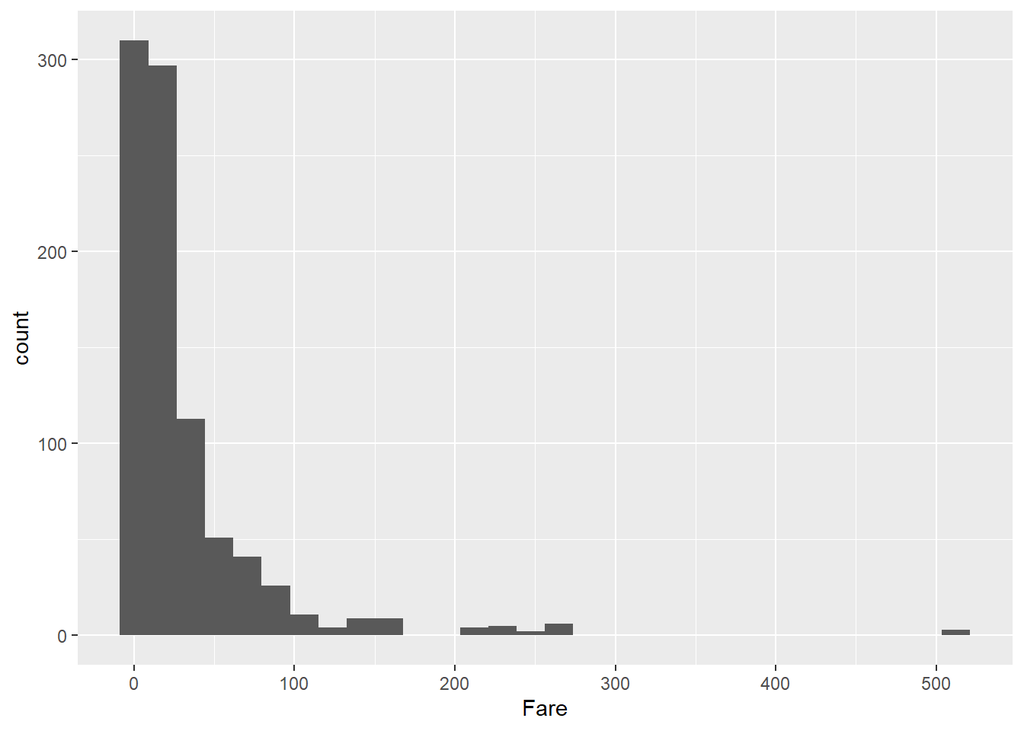

```r
df %>% ggplot()+
  geom_histogram(mapping = aes(x = Fare))
```

- Histogram
- Boxplot

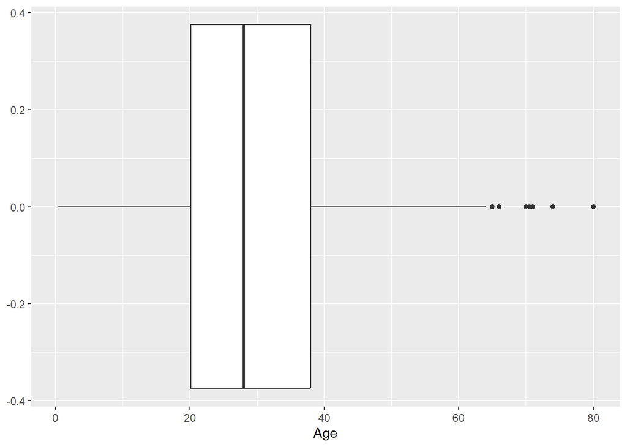

```r
df %>% ggplot()+
  geom_boxplot(mapping = aes(x = Age))
```

## Age is averaged around 28 years old with most ages ranging from infants to mid 60s. After the mid 60s there are a few outliers.

2. For one categorical variable
- Barplot

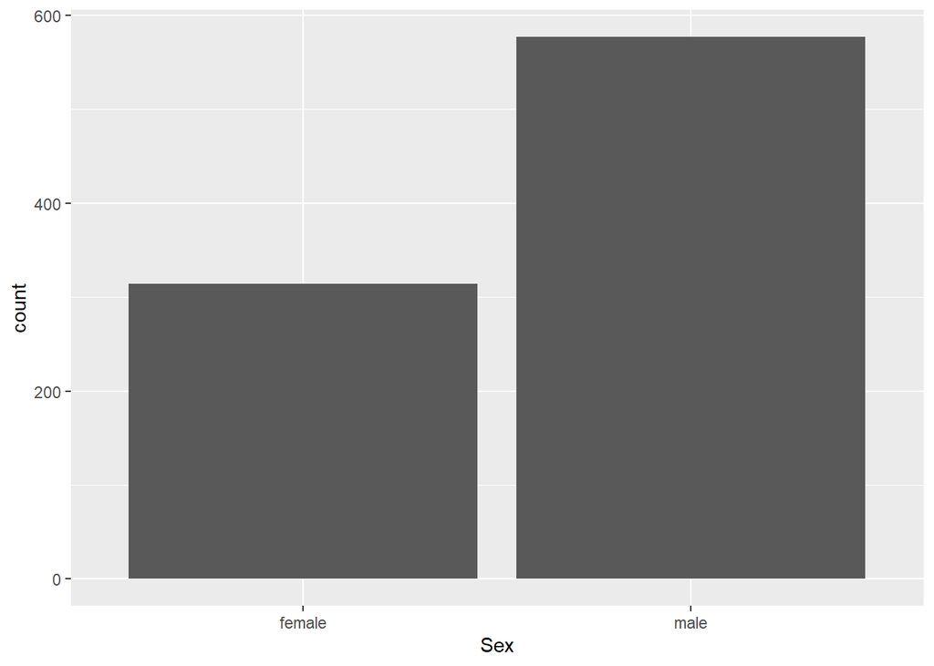

```r
df %>% ggplot()+
  geom_bar(mapping = aes(x = Sex))
```

## Sex of titanic passengers is majority men at around a 70/30 ratio

3. For two continuous variables
- Scatter Plot

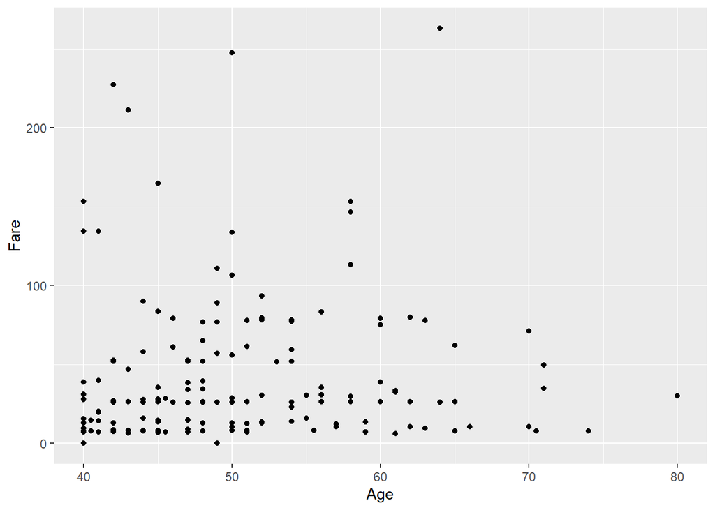

```r
df %>%
  filter(df$Age>=40) %>%
  ggplot()+geom_point(aes(x=Age, y=Fare))
```

Most fares are fairly clustered below 100 when looking at passengers above 40. However, between 40 and 50 there are a fair amount of outliers which start to stop appearing past the age of 50.

- Line Plot

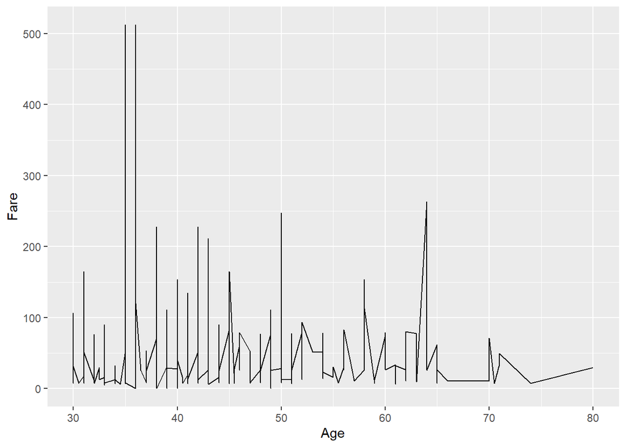

```r
df %>%
  filter(df$Age>=30) %>%
  ggplot()+geom_line(aes(x=Age, y=Fare))
```

When looking at passengers above age of 30, around 35 is where the most expensive tickets are bought.

- Smooth Plot

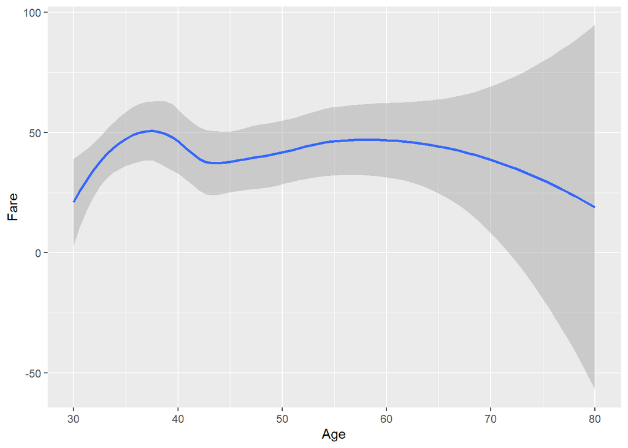

```r
df %>%
  filter(df$Age>=30) %>%
ggplot()+geom_smooth(aes(x=Age, y=Fare))
```

4. For one continuous + one categorical variables
- Density

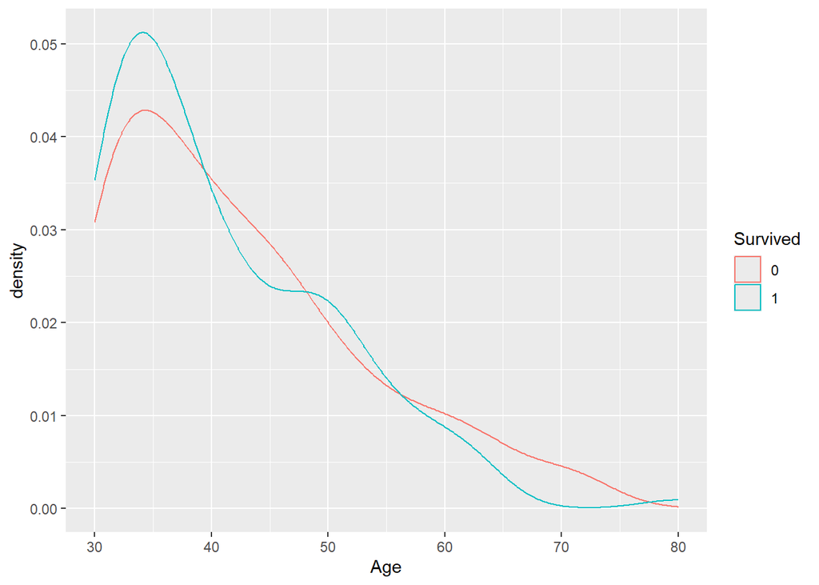

```r
df %>%
  filter(df$Age>=30) %>%
ggplot()+geom_density(aes(x=Age, color= Survived))
```

Survivors of ages around 30-40 are much more densely populated than non survivors. Past 40, the two densities display very similar results aside from minor fluctuations.

- BoxPlot

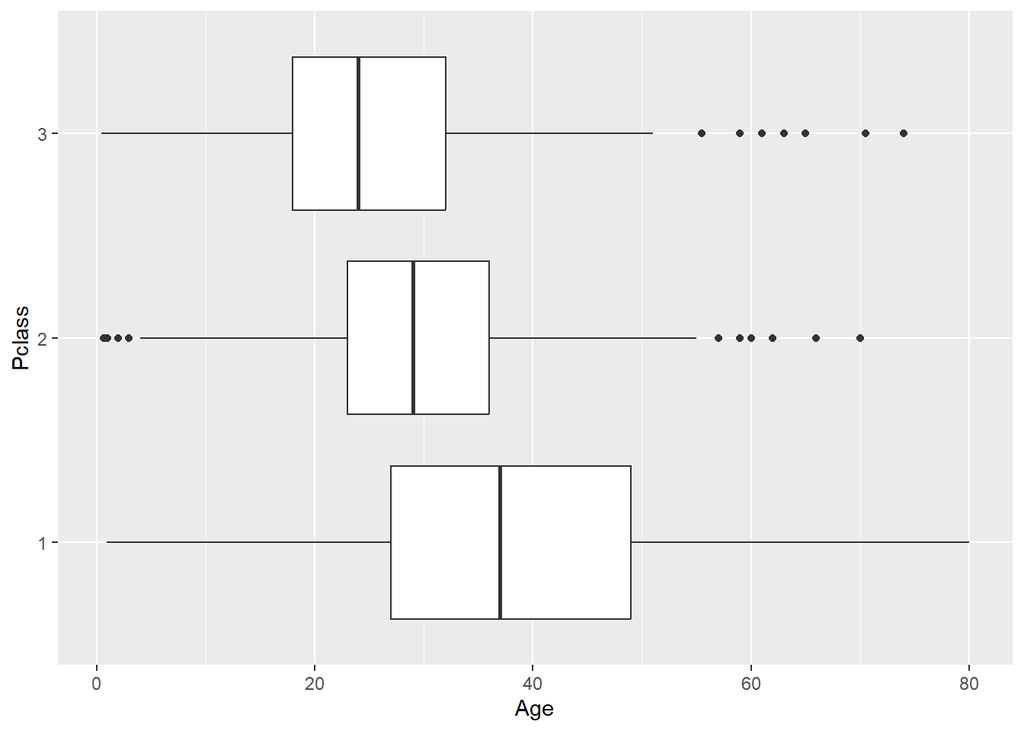

```r
df %>% ggplot()+
  geom_boxplot(mapping = aes(x = Age, y=Pclass))
```

## As pclass increases (from 1-3), a lesser range in the age is observed, however more outliers are present. The average also gets smaller from pclass 1-3, but stays within the 20-40 range.

5. For two categorical variables: barplot

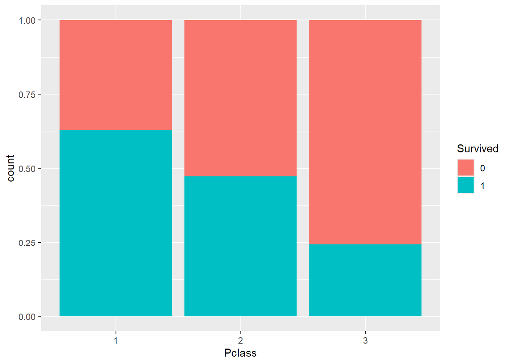

```r
df %>% ggplot()+
  geom_bar(mapping=aes(x=Pclass, fill=Survived), position = 'fill')
```

## As passenger class increases (goes from 1-3), the survived to died ratio gets slimmer

6. A plot that contains three variables

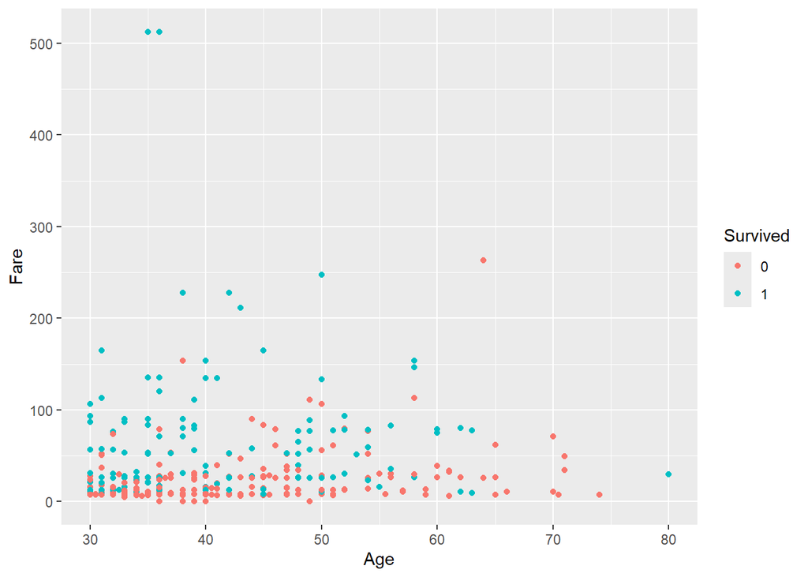

```r
df %>%
  filter(df$Age>=30) %>%
  ggplot() + geom_point(aes(x=Age, y=Fare, color = Survived))
```

Most people aged 30 and above payed within 100 for their fare, however some between 30-50 payed more than 100 and also survived.